# Graphics for Beginners

Matti Meyer

18.02.2015

# Introduction

This is a R markdown document, to show you some of the basics to develop graphics in R. If you want the data set or more information, look at my [Githubpage](https://github.com/MattiMeyer/R-for-Beginners).

# Packages

```r
library(car)
library(knitr)
library(foreign)
library(gplots)
library(psych)
```

# Reading the data

We use a data set from the Department of Psychology of the Univerity of Colorado about Interests of people. You can get it also [here](http://psych.colorado.edu/~carey/Courses/PSYC7291/ClassDataSets.htm). It is a spss data, so we need the package *foreign* to read the data set and to convert it to a data frame.

```r
interest <- as.data.frame(read.spss("/home/matti/R-for-Beginners/interest.sav"))
#file.choose() a good help
```

We have to change the label of the gender, because the plots will look better with it:

```r
interest$gender  <- recode(interest$gender, '1="female" ; 2="male" ')
```

# Graphs for categorial variables

In this chapter we look for nominally and ordinal scaled variables.

## Barplot with absolute frequency

We will create a barplot for the variable “education”. Befor that we use the table() function to build a vector:

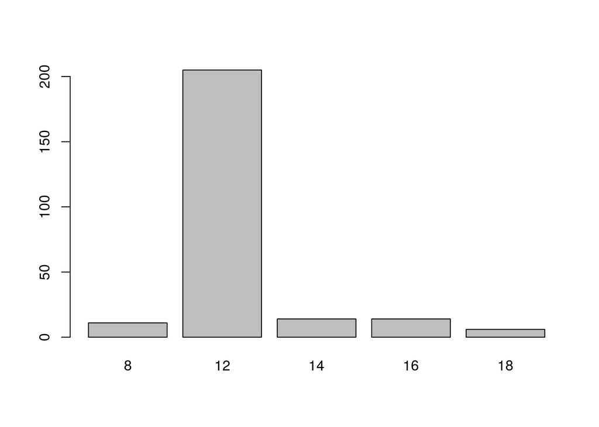

```r
educ<-  table(interest$educ)

barplot(educ)
```

## Barplot with relative frequencys

Relative frequencys show which percentage have some specific education. Just the y axis ist changing.

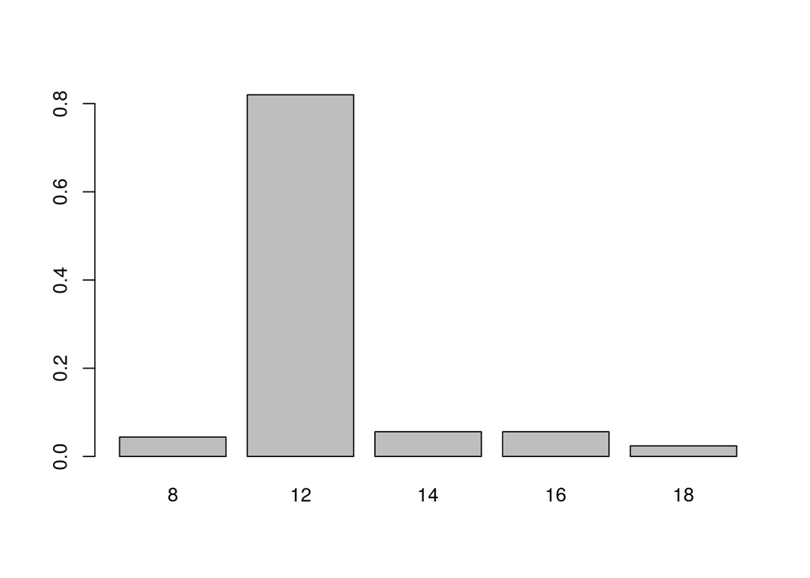

```r
barplot(prop.table(educ))
```

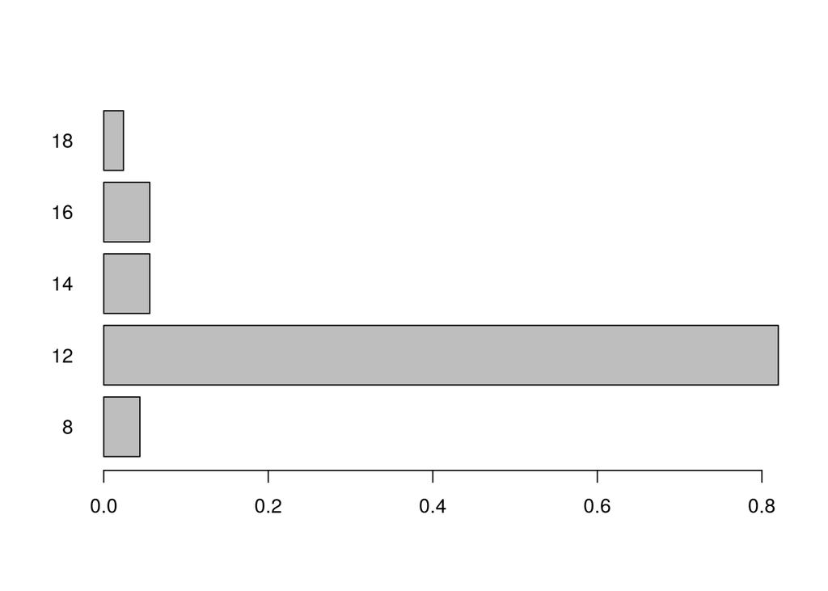

```r
barplot(prop.table(educ), horiz = T ,las=1)
```

To connect two variables, here education and gender:

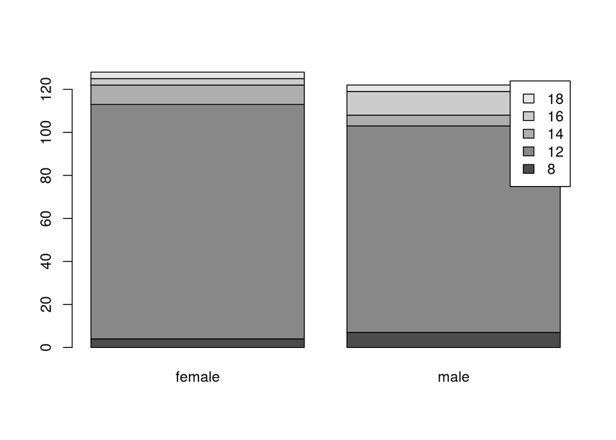

```r
barplot(table(interest$educ, interest$gender), legend=T)
```

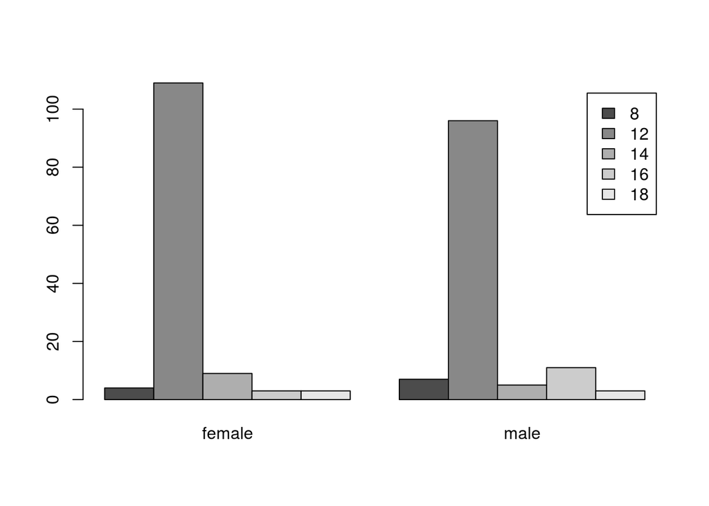

```r
barplot(table(interest$educ, interest$gender), legend=T,beside=T)
```

## Pie chart

What is about some delicious pie?

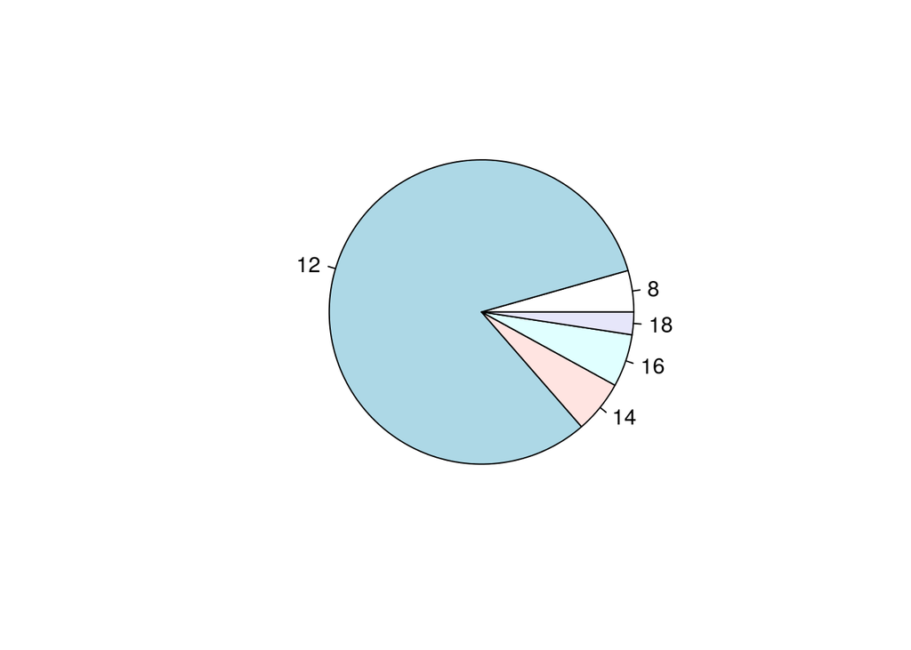

```r
pie(table(interest$educ))
```

# Graphs for metric variables

We build a barplot with the geometry variable:

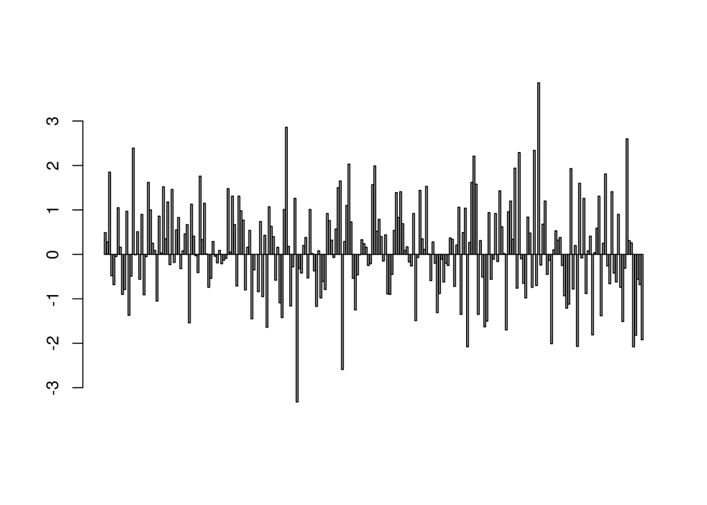

```r
barplot(interest$geometry)
```

Now a histogram:

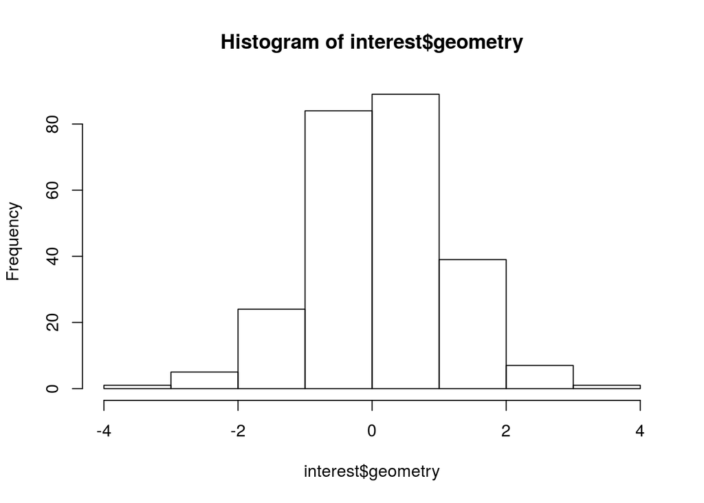

```r
hist(interest$geometry)
```

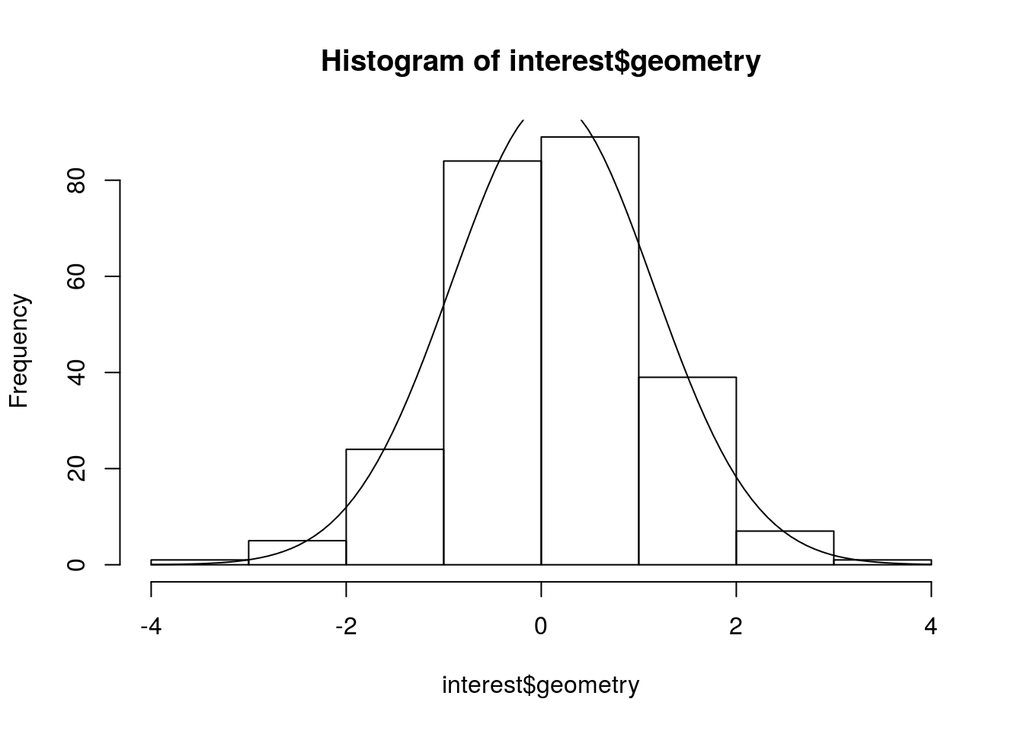

```r
mean  <-  mean(interest$geometry, na.rm=T)
sd  <-  sd(interest$geometry, na.rm = T)
hist(interest$geometry, breaks=10)
curve(dnorm(x, mean, sd)*length(interest$geometry), add=T)
```

Sometimes it is difficult to interpretate a histogram, because it depends on the breaks. So we build a density plot with a continous line:

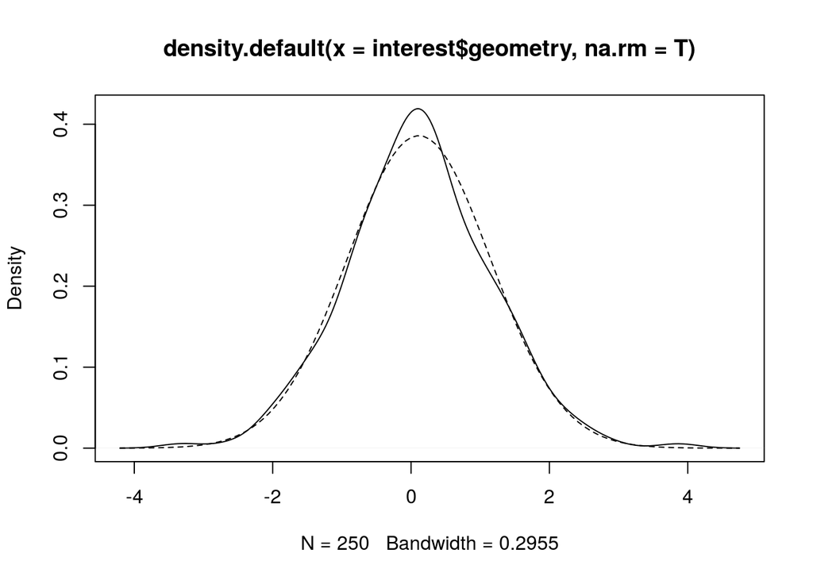

```r
plot(density(interest$geometry, na.rm = T))
curve(dnorm(x, mean, sd), add=T, lty=2)
```

# Boxplots

Boxplots are important for explorative data analysis and show characteristics of the distribution. Here we use the age:

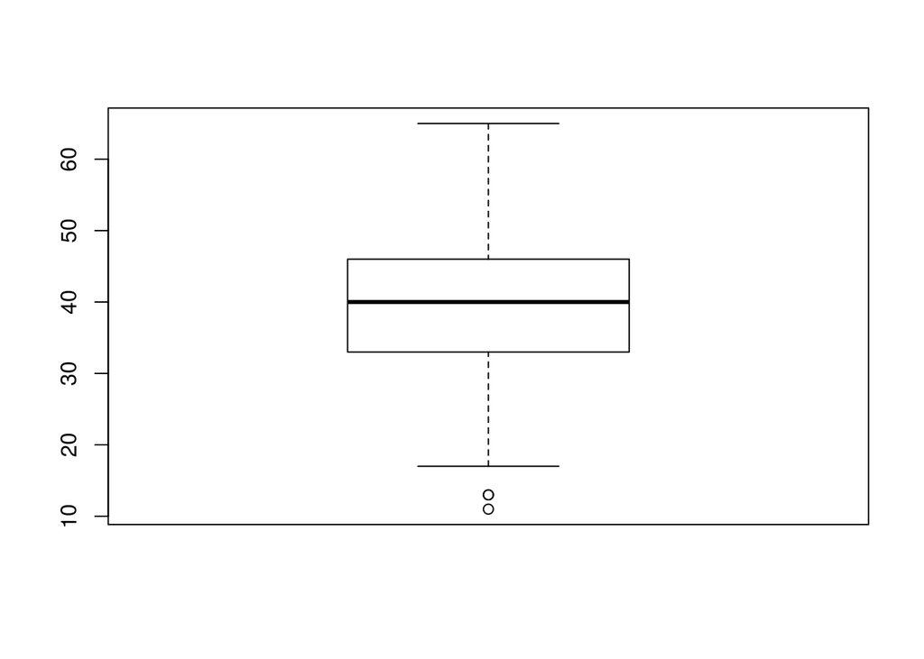

```r
boxplot(interest$age)
```

You can also create some Boxplots together:

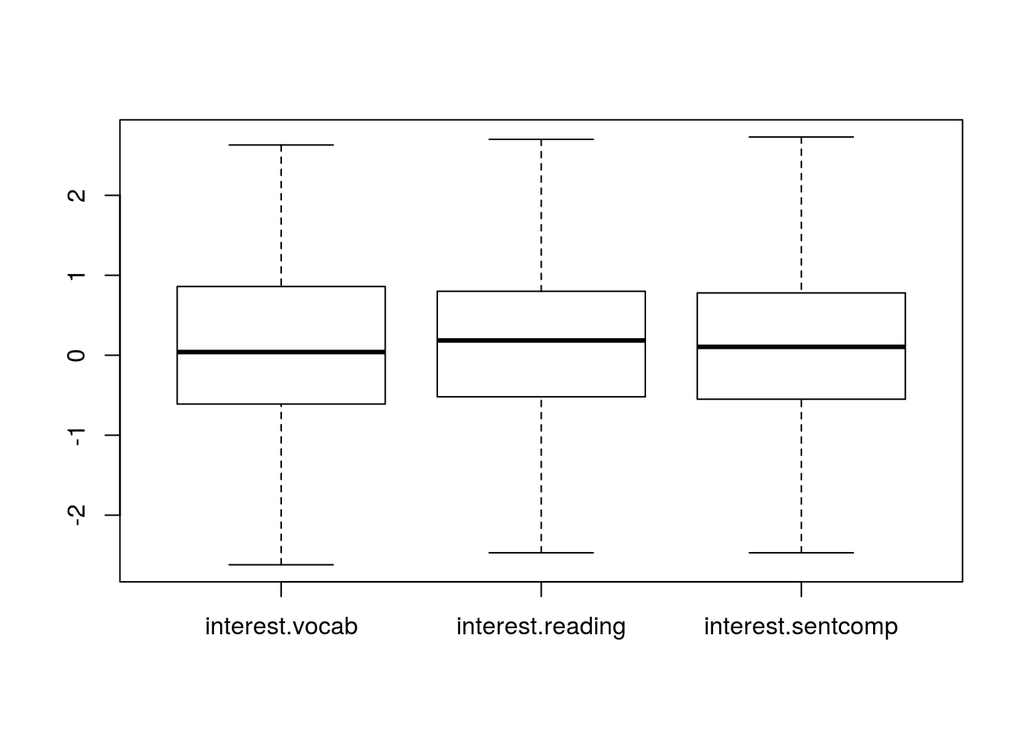

```r
boxplot(data.frame(interest$vocab, interest$reading, interest$sentcomp))
```

To show some Boxplots with informations about some groups (e.g. for women and men) you can use the ~ sign. With the *identify()* you can click on the Boxplots, for example to get to know extreme values.

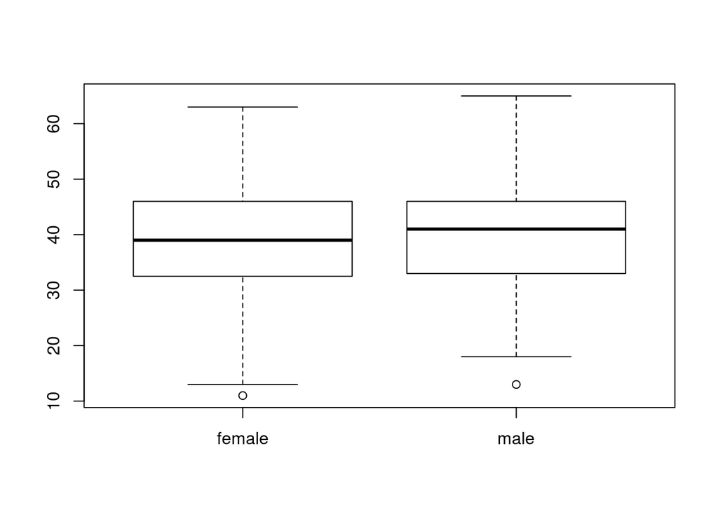

```r
boxplot(interest$age ~  interest$gender)
```

```r
#identify(interest$gender, interest$age)
```

# Barplot for means

We want to visualize the mean of education seperated for men and women. To do that we integrate the *tapply()* function in *barplot()*:

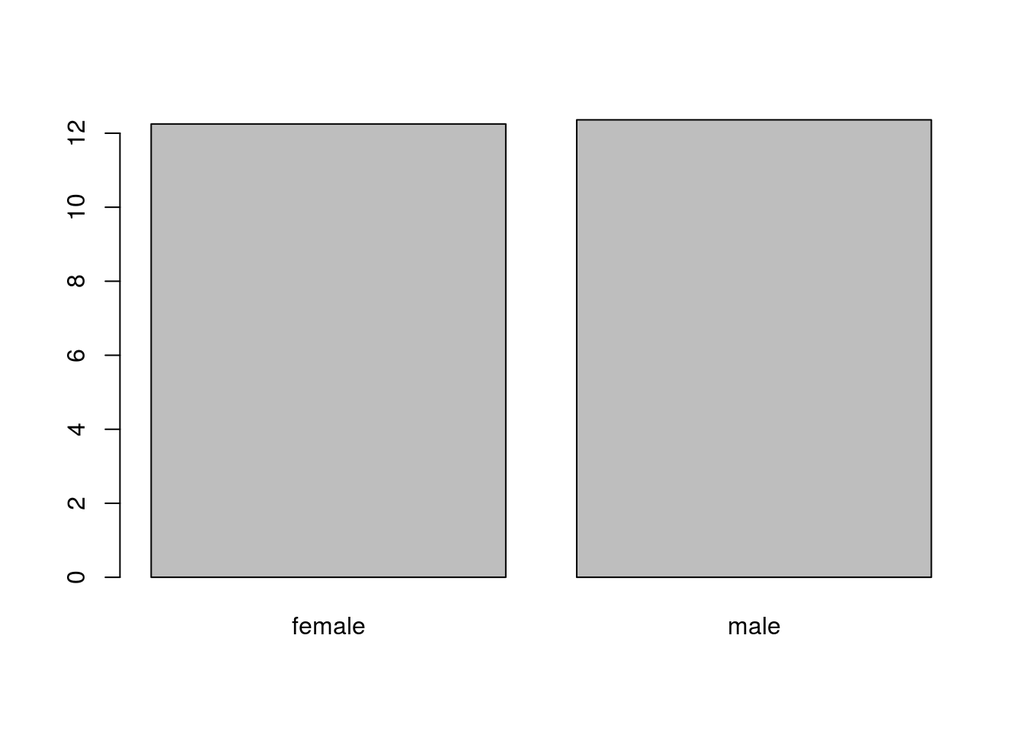

```r
barplot(tapply(interest$educ, interest$gender, mean, na.rm=T))
```

To integrate more means of variables we also use the tapply function:

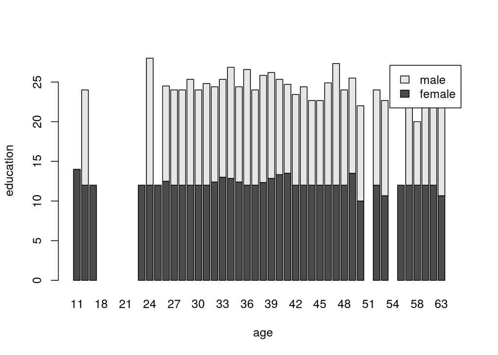

```r
barplot(tapply(interest$educ, data.frame(interest$gender, interest$age), mean, na.rm=T, na.omit=T), legend=T, xlab="age", ylab="education")
```

```r
#for easier interpretations add: beside=TRUE
```

# Error bars

To build an error bar, you can use the package gplots and the *plotmeans()* function. This function build confidence intervals and with p=0.95 we set it for the 95% confidence interval:

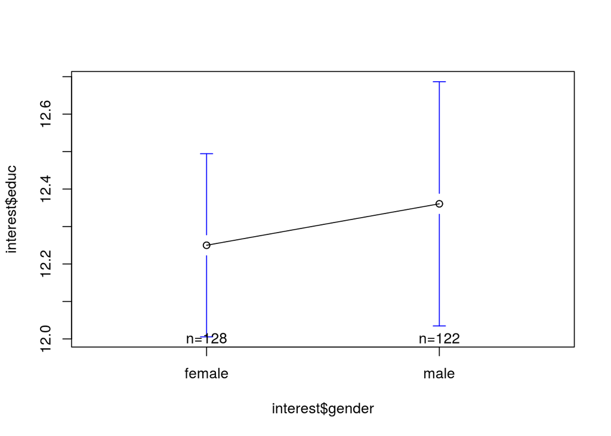

```r
plotmeans(interest$educ~ interest$gender, p=0.95)
```

## Cats-eye plot

If you want to compare the confidence intervalss of some variables use the *error.bars()* function of the psych package. Here we compare geometry and reading:

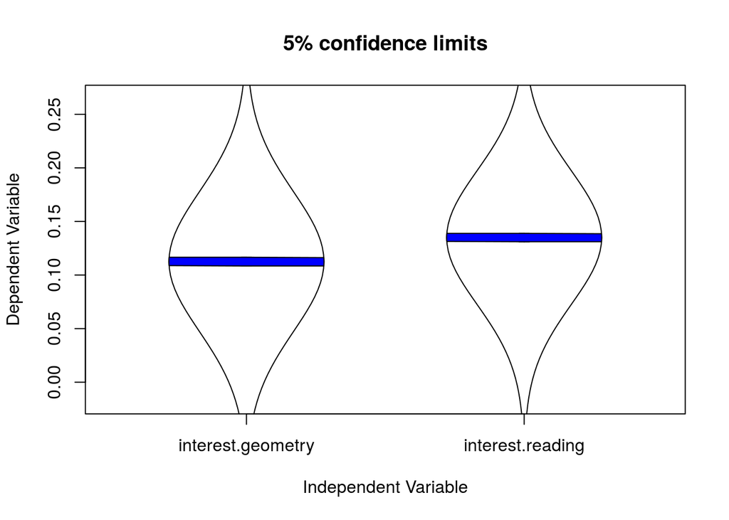

```r
geo.read <- na.omit(data.frame(interest$geometry, interest$reading))
error.bars(geo.read, within=F,alpha=0.95, eyes=T)
```

To compare means of several groups use the *error.bars.by()* function. But you have to build data.frames:

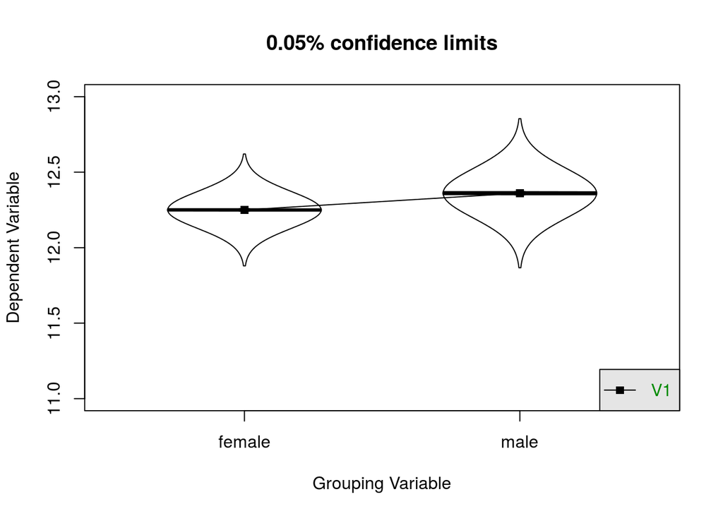

```r
educ <- as.data.frame(na.omit(interest$educ))
gender  <- as.data.frame(na.omit(interest$gender))
error.bars.by(educ, gender, by.var=T, ylim=c(11,13), legend=1, eyes=T, alpha=0.95)
```

## Create own Error bars

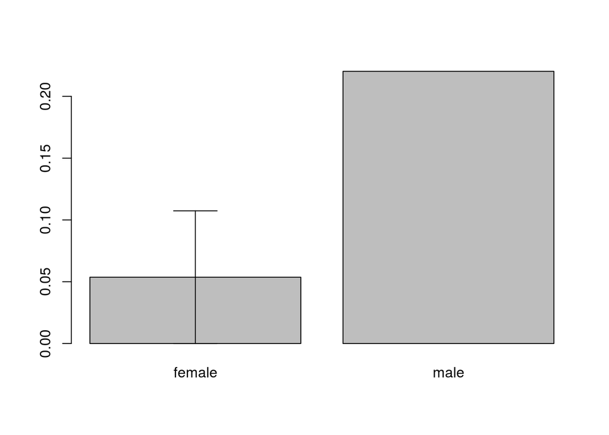

```r
des.read  <-  describeBy(interest$reading,interest$gender, mat=T)
plot.read  <- barplot(des.read$mean, names.arg = des.read$group1)
arrows(plot.read[1], des.read$mean[1]-des.read$mean[1], plot.read[1], des.read$mean[1]+des.read$mean[1], code=3, angle=90)
```

To do this for the second or maybe more blocks in the barplot define the i in the following command. It allows you to get all columns in the table of des.read:

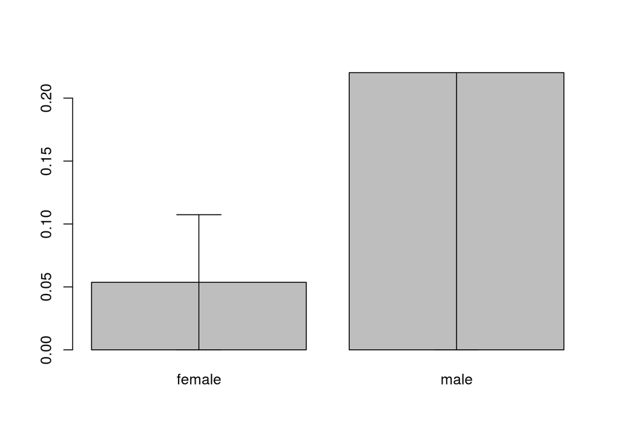

```r
plot.read  <- barplot(des.read$mean, names.arg = des.read$group1)
for(i in 1:nrow(des.read)){
  arrows(plot.read[i], des.read$mean[i]-des.read$mean[i],
         plot.read[i], des.read$mean[i]+des.read$mean[i],
         code=3, angle=90)
}
```

# Q-Q-Plot

When we are interested in a normal distribution histograms can`t help us much. Better are qqplots. The nearer the points are at the line the better is the normal distribution. *qqnorm()* is in the car package:

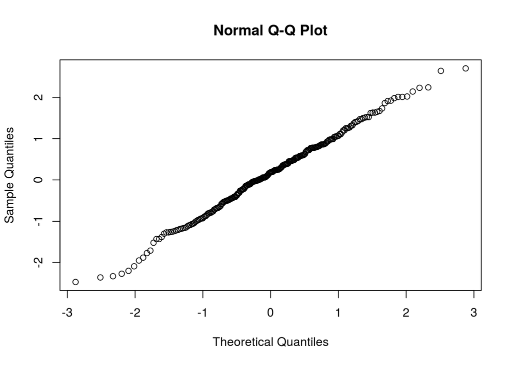

```r
qqnorm(interest$reading)
```

*qqPlot()* is in the car package and shows you the confidence interval. If the point lays near the interval it is normal distributed:

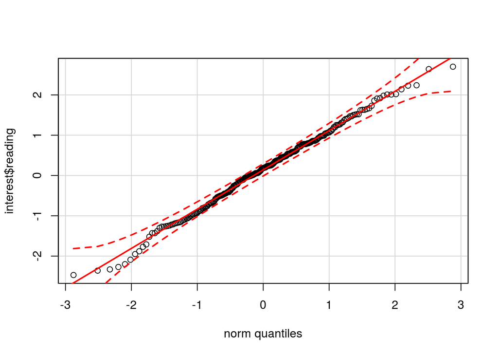

```r
qqPlot(interest$reading)
```

# Scatterplot

To get the connection between two variables use scatterplots with two vectors:

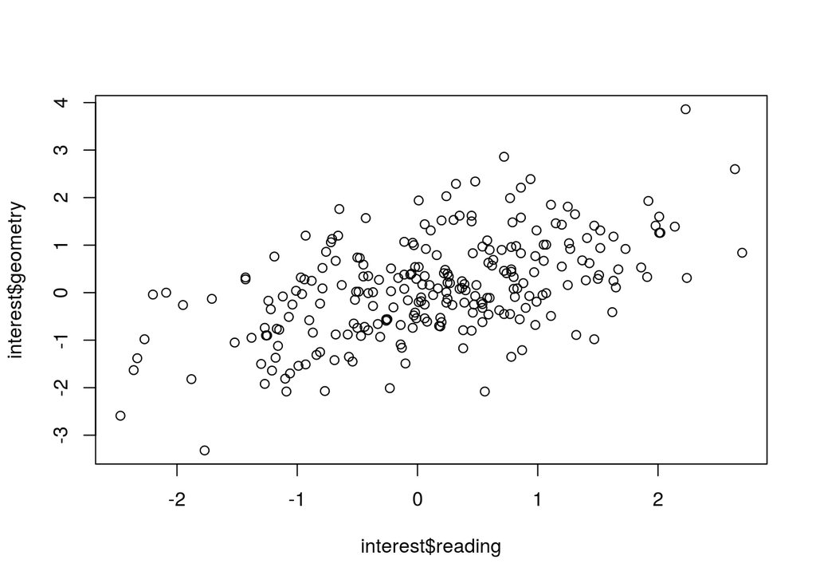

```r
plot(interest$reading, interest$geometry)
```

## Adding a Lowess-curve

A Lowess curve is a nonparametric curve that rebuilds the connection between two variables, but we need varaibles without missing values:

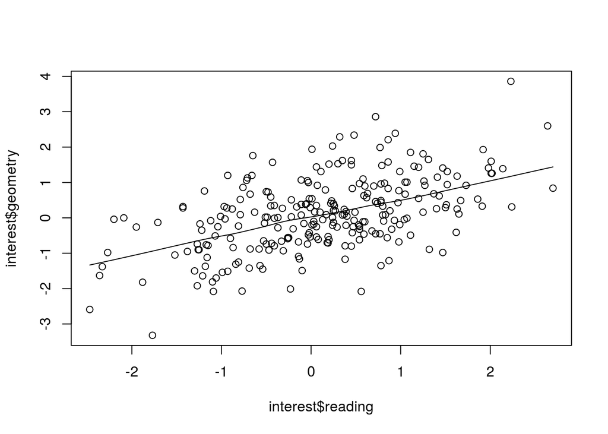

```r
read.geo <- na.omit(data.frame(interest$reading, interest$geometry))
plot(interest$reading, interest$geometry)
lines(lowess(read.geo[,1],read.geo[,2]))
```

## Adding a regression line

To get a regression line use the *abline()* function combinated with a *lm()*. With *identify()* you can again search for extreme values:

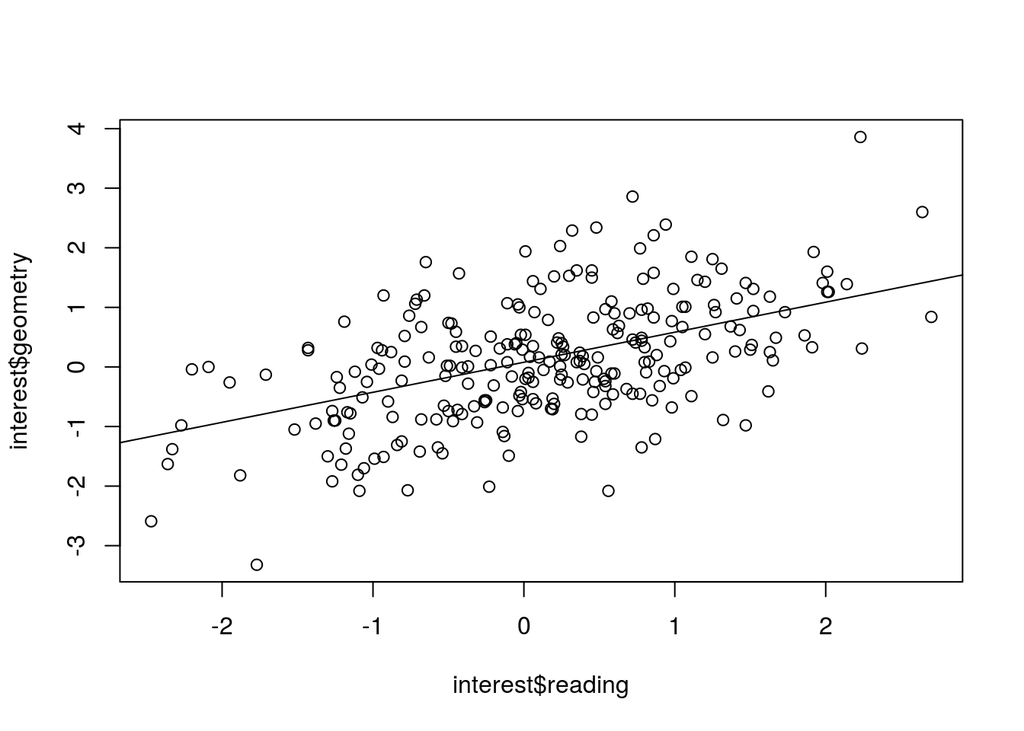

```r
plot(interest$reading, interest$geometry)
abline(lm(interest$reading~interest$geometry))
```

# The plot() function

The output of the *plot()* function changes with the input. Here a table to visualise it:

| plot-function | Diagram |
| --- | --- |
| plot(vector) | Index-diagram |
| plot(factor) | Histogram |
| plot(vector,vector) | scatterplot |
| plot(factor, vector) | boxplot |
| plot(factor, factor) | mosaic-diagram |

# Edit graphs

To change the standard setting use the *par()* function to visit the possibilities for changing something:

```r
par()
help(par)
```

You can add more things in a *plot()* function. Look here:

| Adding | Change |
| --- | --- |
| pch=x | type of points in a scatterplot |
| ces=x | size of points or lettering |
| lty=x | type of line |
| lwd=x | size of the line |
| las=1 | numbers on the y axis are shown horizontal |
| xlab=“x”, ylab=“x” | the names for the axes |
| xlim=c(min, max), ylim=c(min,max) | the scale of the axes |
| main=“text” | heading |
| sub=“text” | subheading |
| col=x | the color (*colors()* gives a full list) |

# Adding elements

To add something write it directly under the *plot()* function, than it will be added to this graph:

| Command | Element |
| --- | --- |
| abline() | straight line |
| arrows() | arrows |
| axis() | lettering axes |
| curve(….,add=TRUE) | functioncurves |
| legend() | legend |
| lines() | lines |
| points() | points |
| symbols() | symbols |
| text() | text |

To get more informations use the *help(abline)* function.